# Machine Learning Assignment

Bradley JK Smith

02 November 2016

## Executive Summary

The objective of this assignment is to build a machine learning model to predict how well participants performed a Unilateral Dumbbell Biceps Curl.

The input data was provided by http://groupware.les.inf.puc-rio.br/har with the ‘classe’ variable defining how the participant performed the exercise. Class ‘A’ corresponds to a correct execution of the exercise while Classes ‘B’ to ‘E’ correspond to typical mistakes that are made.

The features used in the model were outputs from sensors located on the arm, belt, forearm and dumbbell. Features where sensor data was missing were removed from the data set. The input data was split into a training set (60%) and testing set (40%).

Two models were created - a prediction tree and a random forest - by training on the training set and these were evaluated by calculating the accuracy of the prediction on the testing set.

The prediction tree model was interpretable but had poor accuracy with an estimated out of sample error of 0.4505 (95% CI is 0.4395 to 0.4616). The random forest model was a lot more accurate with an estimated out of sample error of 0.0071 (95% CI is 0.0054 to 0.0093) but at the expense of interpretability.

## Get Data & Install libraries

```r
suppressPackageStartupMessages({
  library(caret)
  library(rattle)
  library(rpart.plot)
  })
x <- read.csv('pml-training.csv')
y <- read.csv('pml-testing.csv')
```

## Exploratory Analysis

There are many features which are almost all NA (and often read in as a character).

```r
summary(x[,18:21])
```

```
##  max_roll_belt     max_picth_belt  max_yaw_belt       min_roll_belt
##  Min.   :-94.300   Min.   : 3.00   Length:19622       Min.   :-180.00
##  1st Qu.:-88.000   1st Qu.: 5.00   Class :character   1st Qu.: -88.40
##  Median : -5.100   Median :18.00   Mode  :character   Median :  -7.85
##  Mean   : -6.667   Mean   :12.92                      Mean   : -10.44
##  3rd Qu.: 18.500   3rd Qu.:19.00                      3rd Qu.:   9.05
##  Max.   :180.000   Max.   :30.00                      Max.   : 173.00
##  NA's   :19216     NA's   :19216                      NA's   :19216
```

Because the overwhelming majority of the values were missing for these features (for example, for max_roll_belt, 19,216 of 19,622 were NA) the approach taken was to simply remove any features with any missing data. This also meant that there is no requirement to impute missing values.

In addition, there are identification features (such as time, name, etc.) in the first 7 columns which are not useable so remove these as well. (In fact, we don’t want to use the name of the participant because this would not be transferrable to other users.)

```r
x[,'classe'] <- as.factor(x[,'classe'])
filter <- rep(TRUE, ncol(x))
for( i in 1:159) {
  idx <- is.na(x[,i]) | x[,i] == ""
  if( sum(idx) > 0 | i < 8) { filter[i] <- FALSE }
}
x <- x[,filter]
```

## Data Partitions

A random number seed was set so that the analysis is reproducible. For training the model, 60% of the available data is used. The remaining 40% is used for testing.

```r
set.seed(53421)
inTrain <- createDataPartition(x$classe, p = 0.6, list = FALSE)
training <- x[inTrain, ]
testing <- x[-inTrain, ]
```

## First attempt: Predicting with a tree

For the first model, a prediction tree was used. This will probably be just OK but has the advantage of being interpretable and will aid in determining a improved model.

```r
modFit <- train(classe ~ ., data=training, method='rpart')
modFit
```

```
## CART
##
## 11776 samples
##    52 predictor
##     5 classes: 'A', 'B', 'C', 'D', 'E'
##
## No pre-processing
## Resampling: Bootstrapped (25 reps)
## Summary of sample sizes: 11776, 11776, 11776, 11776, 11776, 11776, ...
## Resampling results across tuning parameters:
##
##   cp          Accuracy   Kappa
##   0.02562886  0.5678110  0.44598590
##   0.04390128  0.4652525  0.28992746
##   0.11414333  0.3295289  0.06758503
##
## Accuracy was used to select the optimal model using  the largest value.
## The final value used for the model was cp = 0.02562886.
```

```r
modFit$finalModel
```

```
## n= 11776
##
## node), split, n, loss, yval, (yprob)
##       * denotes terminal node
##
##   1) root 11776 8428 A (0.28 0.19 0.17 0.16 0.18)
##     2) roll_belt< 130.5 10796 7457 A (0.31 0.21 0.19 0.18 0.11)
##       4) pitch_forearm< -26.7 1056   47 A (0.96 0.045 0 0 0) *
##       5) pitch_forearm>=-26.7 9740 7410 A (0.24 0.23 0.21 0.2 0.12)
##        10) yaw_belt>=169.5 482   50 A (0.9 0.048 0 0.046 0.01) *
##        11) yaw_belt< 169.5 9258 7049 B (0.21 0.24 0.22 0.21 0.13)
##          22) magnet_dumbbell_z< -95.5 1129  453 A (0.6 0.27 0.052 0.049 0.027) *
##          23) magnet_dumbbell_z>=-95.5 8129 6134 C (0.15 0.23 0.25 0.23 0.14)
##            46) pitch_belt< -42.95 488   76 B (0.012 0.84 0.09 0.027 0.027) *
##            47) pitch_belt>=-42.95 7641 5690 C (0.16 0.19 0.26 0.24 0.15)
##              94) magnet_dumbbell_x>=-446.5 3377 2353 B (0.17 0.3 0.093 0.24 0.19)
##               188) roll_belt< 117.5 2065 1167 B (0.16 0.43 0.021 0.13 0.25) *
##               189) roll_belt>=117.5 1312  760 D (0.18 0.096 0.21 0.42 0.095) *
##              95) magnet_dumbbell_x< -446.5 4264 2628 C (0.15 0.11 0.38 0.24 0.12) *
##     3) roll_belt>=130.5 980    9 E (0.0092 0 0 0 0.99) *
```

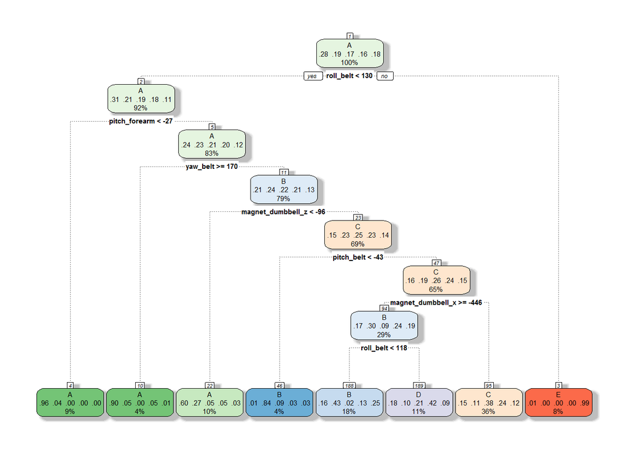

```r
fancyRpartPlot(modFit$finalModel, sub='')
```

This model has roll_belt as the first split point. The graph shows that this does split out some of the ‘E’ class.

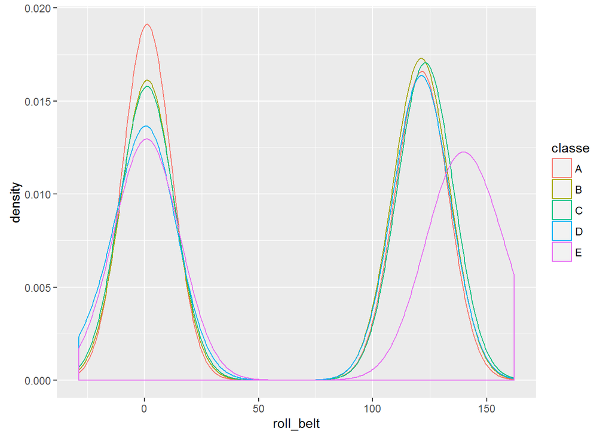

```r
qplot(roll_belt,colour=classe,data=training,geom='density')
```

The predictions from the model show that the accuracy of the model is quite low at 55%

```r
testFit <- predict(modFit, newdata=testing)
cm <- confusionMatrix(testFit, testing$classe)
out_of_sample <- 1-cm$overall[c('Accuracy', 'AccuracyUpper', 'AccuracyLower')]
names(out_of_sample) <- c('OOS', 'OOS_Lower', 'OOS_Uppwer')
cm
```

```
## Confusion Matrix and Statistics
##
##           Reference
## Prediction    A    B    C    D    E
##          A 1358  255   27   65   13
##          B  234  853   68  182  335
##          C  453  339 1082  681  355
##          D  182   71  191  358   79
##          E    5    0    0    0  660
##
## Overall Statistics
##
##                Accuracy : 0.5495
##                  95% CI : (0.5384, 0.5605)
##     No Information Rate : 0.2845
##     P-Value [Acc > NIR] : < 2.2e-16
##
##                   Kappa : 0.4353
##  Mcnemar's Test P-Value : < 2.2e-16
##
## Statistics by Class:
##
##                      Class: A Class: B Class: C Class: D Class: E
## Sensitivity            0.6084   0.5619   0.7909  0.27838  0.45770
## Specificity            0.9359   0.8706   0.7178  0.92027  0.99922
## Pos Pred Value         0.7905   0.5102   0.3718  0.40636  0.99248
## Neg Pred Value         0.8574   0.8923   0.9421  0.86676  0.89110
## Prevalence             0.2845   0.1935   0.1744  0.16391  0.18379
## Detection Rate         0.1731   0.1087   0.1379  0.04563  0.08412
## Detection Prevalence   0.2190   0.2131   0.3709  0.11229  0.08476
## Balanced Accuracy      0.7721   0.7162   0.7544  0.59933  0.72846
```

```r
out_of_sample
```

```
##        OOS  OOS_Lower OOS_Uppwer
##  0.4505480  0.4394951  0.4616377
```

## Second attempt: Random forest

Given that the prediction tree showed some promise, the next step is trying a random forest model. This is likely to yield a more accurate model but will be less interpretable.

As the time taken to train the model increases significantly, 100 trees were chosen.

```r
time_start <- Sys.time()
modFit2 <- train(classe ~ ., data=training, method='rf', ntree=100)
Sys.time() - time_start
```

```
## Time difference of 14.4387 mins
```

The confusion matrix shows that the performance has increased dramatically.

```r
testFit2 <- predict(modFit2, newdata=testing)
cm2 <- confusionMatrix(testFit2, testing$classe)
out_of_sample2 <- 1-cm2$overall[c('Accuracy', 'AccuracyUpper', 'AccuracyLower')]
names(out_of_sample2) <- c('OOS', 'OOS_Lower', 'OOS_Uppwer')
cm2
```

```
## Confusion Matrix and Statistics
##
##           Reference
## Prediction    A    B    C    D    E
##          A 2230   13    0    0    0
##          B    2 1499    5    0    1
##          C    0    6 1361   13    4
##          D    0    0    2 1270    7
##          E    0    0    0    3 1430
##
## Overall Statistics
##
##                Accuracy : 0.9929
##                  95% CI : (0.9907, 0.9946)
##     No Information Rate : 0.2845
##     P-Value [Acc > NIR] : < 2.2e-16
##
##                   Kappa : 0.991
##  Mcnemar's Test P-Value : NA
##
## Statistics by Class:
##
##                      Class: A Class: B Class: C Class: D Class: E
## Sensitivity            0.9991   0.9875   0.9949   0.9876   0.9917
## Specificity            0.9977   0.9987   0.9964   0.9986   0.9995
## Pos Pred Value         0.9942   0.9947   0.9834   0.9930   0.9979
## Neg Pred Value         0.9996   0.9970   0.9989   0.9976   0.9981
## Prevalence             0.2845   0.1935   0.1744   0.1639   0.1838
## Detection Rate         0.2842   0.1911   0.1735   0.1619   0.1823
## Detection Prevalence   0.2859   0.1921   0.1764   0.1630   0.1826
## Balanced Accuracy      0.9984   0.9931   0.9957   0.9931   0.9956
```

```r
out_of_sample2
```

```
##         OOS   OOS_Lower  OOS_Uppwer
## 0.007137395 0.005395885 0.009258615
```

## Conclusion

The prediction tree gives an interpretable model but with low accuracy of 0.5495 on the testing sample. The estimated out of sample error is 0.4505 (95% CI is 0.4395 to 0.4616).

The random forest improves the accuracy of the prediction to 0.9929 but at the expense of interpretability. The estimated out of sample error is 0.0071 (95% CI is 0.0054 to 0.0093).

## Prediction

```r
predictFit <- predict(modFit2, y)
predictFit
```

```
##  [1] B A B A A E D B A A B C B A E E A B B B
## Levels: A B C D E
```